# Data Exploration Methods in R

Data Exploration is a pre-requisite for any model building.The file gives a quick glimpse of some of the key data exploration techniques in R.Lets load the data and view the kind of data that’s present

```r
raw_df = read.csv("Test_Data.csv")
head(raw_df)
```

```
##   SLNO Candidate.Ref DOJ.Extended Duration.to.accept.offer Notice.period
## 1    1       2110407          Yes                       14            30
## 2    2       2112635           No                       18            30
## 3    3       2112838           No                        3            45
## 4    4       2115021           No                       26            30
## 5    5       2115125          Yes                        1           120
## 6    6       2117167          Yes                       17            30
##   Offered.band Pecent.hike.expected.in.CTC Percent.hike.offered.in.CTC
## 1           E2                      -20.79                       13.16
## 2           E2                       50.00                      320.00
## 3           E2                       42.84                       42.84
## 4           E2                       42.84                       42.84
## 5           E2                       42.59                       42.59
## 6           E1                       42.83                       42.83
##   Percent.difference.CTC Joining.Bonus Candidate.relocate.actual Gender
## 1                  42.86            No                        No Female
## 2                 180.00            No                        No   Male
## 3                   0.00            No                        No   Male
## 4                   0.00            No                        No   Male
## 5                   0.00            No                       Yes   Male
## 6                   0.00            No                        No   Male
##    Candidate.Source Rex.in.Yrs   LOB Location Age Status
## 1            Agency          7   ERS    Noida  34 Joined
## 2 Employee Referral          8 INFRA  Chennai  34 Joined
## 3            Agency          4 INFRA    Noida  27 Joined
## 4 Employee Referral          4 INFRA    Noida  34 Joined
## 5 Employee Referral          6 INFRA    Noida  34 Joined
## 6 Employee Referral          2 INFRA    Noida  34 Joined
```

Another good way to quickly see the data is ‘View’ which presents data in a tabular format

```r
View(raw_df)
```

We can view the summary. Summary gives a quick snapshot of the data values. For continuous variables, it gives the 5 metrics of range, mean and quartiles. For categorical variables, it gives a count by category. When the categories are more, it clubs it against ‘others’

```r
summary(raw_df)
```

```
##       SLNO       Candidate.Ref     DOJ.Extended Duration.to.accept.offer
##  Min.   :    1   Min.   :2109586   No :4788     Min.   :  0.00
##  1st Qu.: 3208   1st Qu.:2386476   Yes:4207     1st Qu.:  3.00
##  Median : 5976   Median :2807482                Median : 10.00
##  Mean   : 5971   Mean   :2843647                Mean   : 21.43
##  3rd Qu.: 8739   3rd Qu.:3300060                3rd Qu.: 33.00
##  Max.   :12333   Max.   :3836076                Max.   :224.00
##
##  Notice.period    Offered.band Pecent.hike.expected.in.CTC
##  Min.   :  0.00   E0: 211      Min.   :-68.83
##  1st Qu.: 30.00   E1:5568      1st Qu.: 27.27
##  Median : 30.00   E2:2711      Median : 40.00
##  Mean   : 39.29   E3: 505      Mean   : 43.86
##  3rd Qu.: 60.00                3rd Qu.: 53.85
##  Max.   :120.00                Max.   :359.77
##
##  Percent.hike.offered.in.CTC Percent.difference.CTC Joining.Bonus
##  Min.   :-60.53              Min.   :-67.270        No :8578
##  1st Qu.: 22.09              1st Qu.: -8.330        Yes: 417
##  Median : 36.00              Median :  0.000
##  Mean   : 40.66              Mean   : -1.574
##  3rd Qu.: 50.00              3rd Qu.:  0.000
##  Max.   :471.43              Max.   :300.000
##
##  Candidate.relocate.actual    Gender              Candidate.Source
##  No :7705                  Female:1551   Agency           :2585
##  Yes:1290                  Male  :7444   Direct           :4801
##                                          Employee Referral:1609
##
##
##
##
##    Rex.in.Yrs          LOB            Location         Age
##  Min.   : 0.000   INFRA  :2850   Chennai  :3150   Min.   :20.00
##  1st Qu.: 3.000   ERS    :2426   Noida    :2727   1st Qu.:27.00
##  Median : 4.000   BFSI   :1396   Bangalore:2230   Median :29.00
##  Mean   : 4.239   ETS    : 691   Hyderabad: 341   Mean   :29.91
##  3rd Qu.: 6.000   CSMP   : 579   Mumbai   : 197   3rd Qu.:34.00
##  Max.   :24.000   AXON   : 568   Gurgaon  : 146   Max.   :60.00
##                   (Other): 485   (Other)  : 204
##         Status
##  Joined    :7313
##  Not Joined:1682
##
##
##
##
##
```

To see the columns in the dataset

```r
colnames(raw_df)
```

```
##  [1] "SLNO"                        "Candidate.Ref"
##  [3] "DOJ.Extended"                "Duration.to.accept.offer"
##  [5] "Notice.period"               "Offered.band"
##  [7] "Pecent.hike.expected.in.CTC" "Percent.hike.offered.in.CTC"
##  [9] "Percent.difference.CTC"      "Joining.Bonus"
## [11] "Candidate.relocate.actual"   "Gender"
## [13] "Candidate.Source"            "Rex.in.Yrs"
## [15] "LOB"                         "Location"
## [17] "Age"                         "Status"
```

A very useful way to visualize data and the data types at one place

```r
str(raw_df)
```

```
## 'data.frame':    8995 obs. of  18 variables:
##  $ SLNO                       : int  1 2 3 4 5 6 7 9 11 12 ...
##  $ Candidate.Ref              : int  2110407 2112635 2112838 2115021 2115125 2117167 2119124 2127572 2138169 2143362 ...
##  $ DOJ.Extended               : Factor w/ 2 levels "No","Yes": 2 1 1 1 2 2 2 2 1 1 ...
##  $ Duration.to.accept.offer   : int  14 18 3 26 1 17 37 16 1 6 ...
##  $ Notice.period              : int  30 30 45 30 120 30 30 0 30 30 ...
##  $ Offered.band               : Factor w/ 4 levels "E0","E1","E2",..: 3 3 3 3 3 2 3 2 2 2 ...
##  $ Pecent.hike.expected.in.CTC: num  -20.8 50 42.8 42.8 42.6 ...
##  $ Percent.hike.offered.in.CTC: num  13.2 320 42.8 42.8 42.6 ...
##  $ Percent.difference.CTC     : num  42.9 180 0 0 0 ...
##  $ Joining.Bonus              : Factor w/ 2 levels "No","Yes": 1 1 1 1 1 1 1 1 1 1 ...
##  $ Candidate.relocate.actual  : Factor w/ 2 levels "No","Yes": 1 1 1 1 2 1 1 1 1 1 ...
##  $ Gender                     : Factor w/ 2 levels "Female","Male": 1 2 2 2 2 2 2 1 1 2 ...
##  $ Candidate.Source           : Factor w/ 3 levels "Agency","Direct",..: 1 3 1 3 3 3 3 2 3 3 ...
##  $ Rex.in.Yrs                 : int  7 8 4 4 6 2 7 8 3 3 ...
##  $ LOB                        : Factor w/ 9 levels "AXON","BFSI",..: 5 8 8 8 8 8 8 7 2 3 ...
##  $ Location                   : Factor w/ 11 levels "Ahmedabad","Bangalore",..: 9 3 9 9 9 9 9 9 5 3 ...
##  $ Age                        : int  34 34 27 34 34 34 32 34 26 34 ...
##  $ Status                     : Factor w/ 2 levels "Joined","Not Joined": 1 1 1 1 1 1 1 1 1 1 ...
```

Get the count of data in the dataset

```r
nrow(raw_df)
```

```
## [1] 8995
```

Get count by some particular categorical variable

```r
library(plyr)
count(raw_df,'LOB')
```

```
##          LOB freq
## 1       AXON  568
## 2       BFSI 1396
## 3       CSMP  579
## 4        EAS  346
## 5        ERS 2426
## 6        ETS  691
## 7 Healthcare  124
## 8      INFRA 2850
## 9        MMS   15
```

When we view the summary, we are automatically led to more questions. Questions like - 1. Does the candidate source have a bearing on status of joining 2. Do candidates joining decision get influenced by their notice period 3. How has the joining been across different offered bands

Lets see how we can answer some of these questions using visualizations

Lets first view the historam of the duration to accept. We can use histograms for all continuous variables.

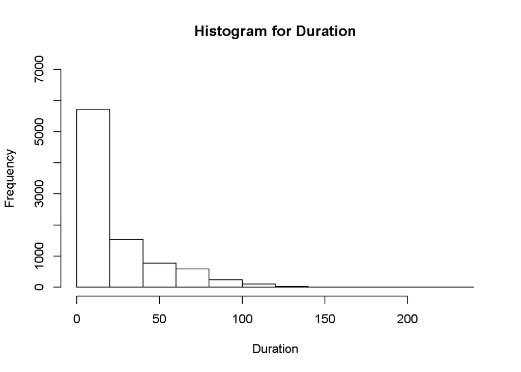

```r
hist(raw_df$Duration.to.accept.offer,
     main="Histogram for Duration",
     xlab="Duration",ylim=c(0,7000))
```

How does the duration to accept an offer vary across LOB for people who join Box plot of Duration vs LOB is a visualization by which we can view a categorical vs a continuous variable

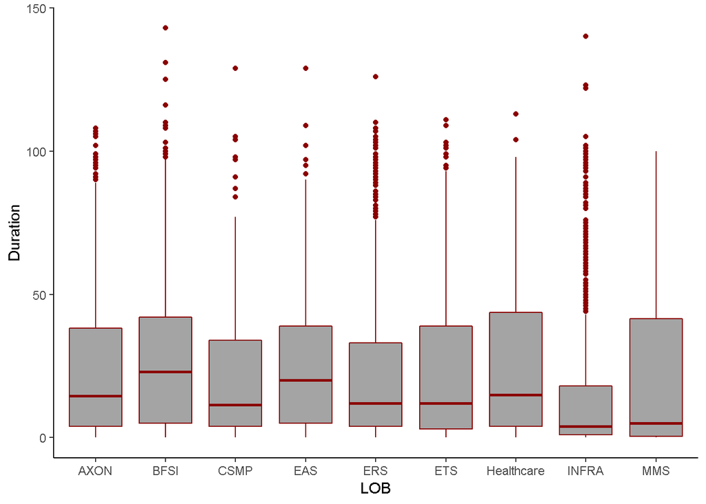

```r
library(ggplot2)
joined <- raw_df[raw_df$Status=="Joined",]
p <- ggplot(data = joined, mapping = aes(x = joined$LOB, y = joined$Duration.to.accept.offer)) +
  geom_boxplot(fill='#A4A4A4',color="darkred") + theme_classic() +xlab("LOB") + ylab("Duration")
p
```

If we want to see whether the Notice period differs for those who joined versus those who didnt join

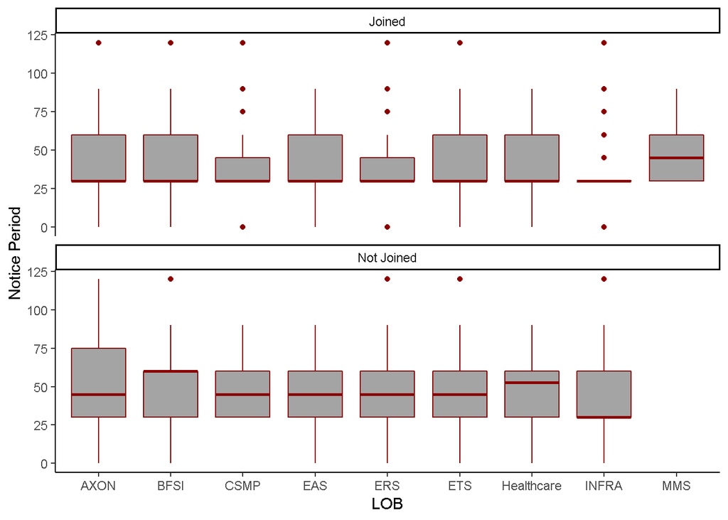

```r
p <- ggplot(data = raw_df, mapping = aes(x = raw_df$LOB, y = raw_df$Notice.period)) +
  geom_boxplot(fill='#A4A4A4',color="darkred") +xlab("LOB") +ylab("Notice Period")
p <- p + facet_wrap(~Status,nrow=2) + theme_classic()
p
```

We could view a categorical variable vs another categorical variable using Stacked bar charts. If we want to use both LOB and Status, then first we need to group the data to get the specific grouped counts.

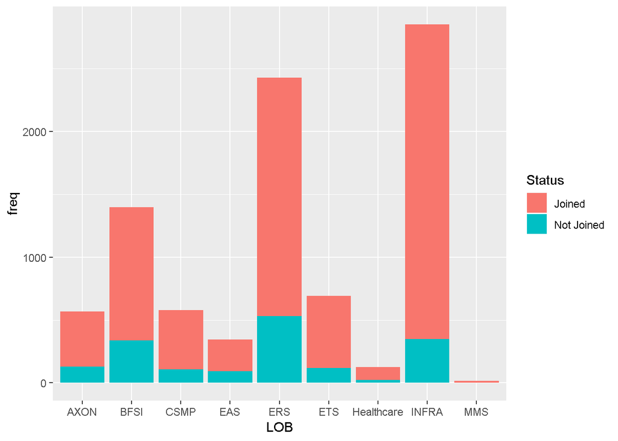

```r
grouped <- count(raw_df,c("LOB","Status"))

p <- ggplot() + geom_bar(aes(y = freq, x = LOB, fill = Status), data = grouped,
                          stat="identity")
p
```

Continuous vs continuous variables can be viewed as Scatter plots. As is evident, Percent hike expected and percent hike offered should be correlated, but lets just view it as a scatter plot

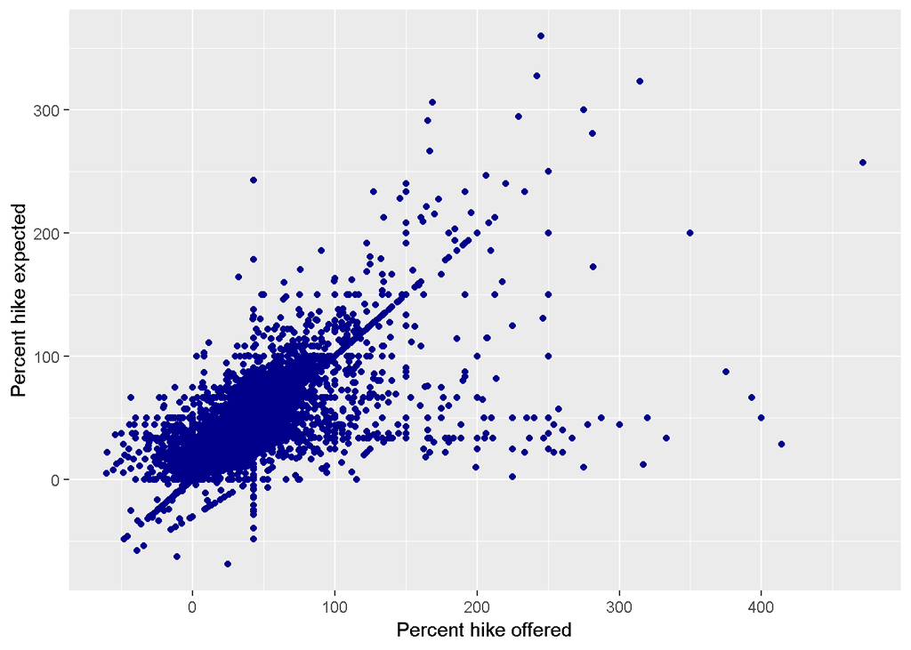

```r
p <- ggplot(raw_df,aes(y = Pecent.hike.expected.in.CTC, x = Percent.hike.offered.in.CTC)) + geom_point(color="darkblue") + labs(x="Percent hike offered",y="Percent hike expected")
p
```

If we now want to see whether the difference in percent hike offered vs expected had anything to do with joining, we can simply add a legend to the plot above.

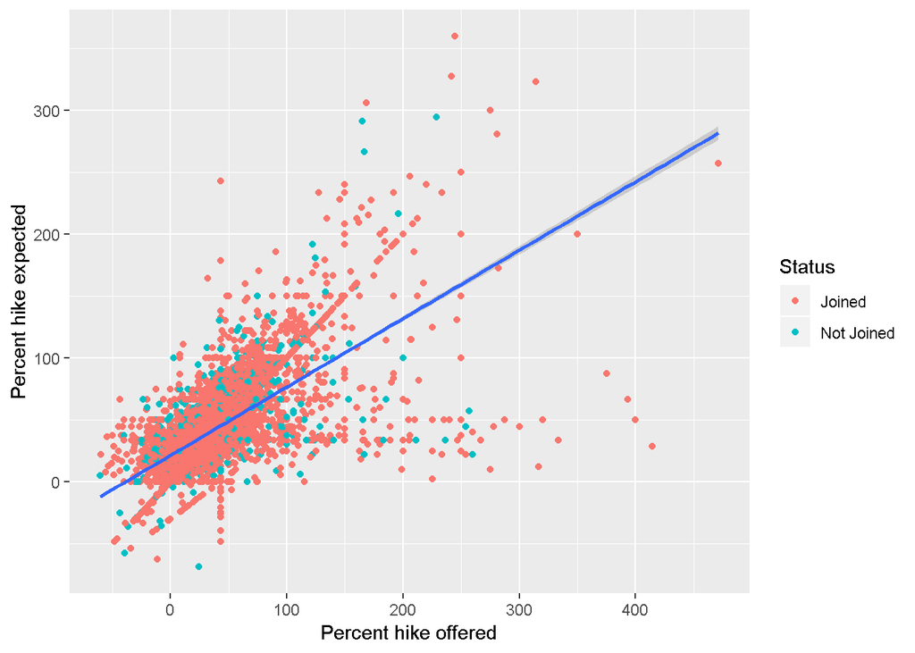

```r
p <- ggplot(raw_df,aes(y = Pecent.hike.expected.in.CTC, x = Percent.hike.offered.in.CTC)) + geom_point(aes(col=Status)) + labs(x="Percent hike offered",y="Percent hike expected")
p <- p + geom_smooth(method="lm")
p
```

At times we need to check variables which show zero variance. If a particular feature has near zero variance, it suffers from two problems. Firstly, such kind of feature wont really add to any predictive power when using this dataset for a model building. Secondly, during a cross validation split, if a variable is severely imbalanced, then it wont be distibuted to all the validation splits, resulting in a model sometimes seeing a value and sometimes not seeing it at all. The Near Zero Variance in caret package is worth looking at for this purpose.

```r
library(caret)
nzv <- nearZeroVar(raw_df, saveMetrics= TRUE)
head(nzv)
```

```
##                          freqRatio percentUnique zeroVar   nzv
## SLNO                      1.000000  100.00000000   FALSE FALSE
## Candidate.Ref             1.000000  100.00000000   FALSE FALSE
## DOJ.Extended              1.138103    0.02223457   FALSE FALSE
## Duration.to.accept.offer  1.113606    1.51195108   FALSE FALSE
## Notice.period             2.939031    0.07782101   FALSE FALSE
## Offered.band              2.053855    0.04446915   FALSE FALSE
```

The freqRatio gives the ratio of the most frequent value by the next most freq value. percentUnique gives the number of unique values divided by the total number of samples. These values should be examined to understand if any feature should be ignored.

A very important part of data exploration is to discover outliers. Outliers in univariate analysis can be discovered visually through box plots and also through histograms. Outliers in multivariate analysis normally can be seen when viewing multivariate plots.

The next important thing to do, is to do understand missing values and decide on a suitable strategy.

We will explore more on preprocessing in the next section.